*toxins*

[figure not shown]

[figure not shown]

[figure not shown]

*Review*

**Toxic Animal-Based Medicinal Materials Can Be Effective in**

**Treating Endometriosis: A Scoping Review**

**Su-In Hwang** <sup>**1**</sup>

**, Young-Jin Yoon** <sup>**1,2**</sup>**, Soo-Hyun Sung** <sup>**3**</sup>

**, Ki-Tae Ha** <sup>**4**</sup>

**and Jang-Kyung Park** <sup>**1,2,**</sup>*

**Citation:** Hwang, S.-I.; Yoon, Y.-J.;

Sung, S.-H.; Ha, K.-T.; Park, J.-K.

Toxic Animal-Based Medicinal

Materials Can Be Effective in Treating

Endometriosis: A Scoping Review.

*Toxins* **2021**, *13*, 145. https://doi.org/

10.3390/toxins13020145

Received: 28 December 2020

Accepted: 12 February 2021

Published: 14 February 2021

**Publisher’s Note:** MDPI stays neutral

with regard to jurisdictional claims in

published maps and institutional afﬁl-

iations.

**Copyright:** © 2021 by the authors.

Licensee MDPI, Basel, Switzerland.

This article is an open access article

distributed

under

the

terms

and

conditions of the Creative Commons

Attribution (CC BY) license (https://

creativecommons.org/licenses/by/

4.0/).

1

Department of Korean Medicine Obstetrics and Gynecology, Pusan National University Korean Medicine

Hospital, Yangsan 50612, Korea; hwangsi1216@gmail.com (S.-I.H.); yyj@pusan.ac.kr (Y.-J.Y.)

2

Division of Clinical Medicine, School of Korean Medicine, Pusan National University, Yangsan 50612, Korea

3

Department of Policy Development, National Development Institute of Korean Medicine, Seoul 04554, Korea;

koyote10010@nikom.or.kr

4

Department of Korean Medical Science, School of Korean Medicine, Pusan National University,

Yangsan 50612, Korea; hagis@pusan.ac.kr

Correspondence: vivat314@pusan.ac.kr; Tel.: +82-55-360-5978; Fax: +82-55-360-5890

**Abstract:** Animal toxins and venoms have recently been developed as cancer treatments possessing

tumor cell growth-inhibitory, antiangiogenesis, and proapoptotic effects. Endometriosis is a common

benign gynecological disorder in reproductive-age women, and no deﬁnite treatment for this disorder

is without severe side effects. As endometriosis and malignant tumors share similar characteristics

(progressive, invasive, estrogen-dependent growth, and recurrence), animal toxins and venoms are

thought to be effective against endometriosis. The objective of this study was to outline studies

using toxic animal-based medicinal materials (TMM) as endometriosis treatment and to explore

its clinical applicability. Preclinical and clinical studies using TMM were searched for in four

databases from inception to October 2020. A total of 20 studies of TMM on endometriosis were

reducing, and possible anti-inﬂammatory effects. TMM are thus considered promising sources for

the development of an effective treatment method for endometriosis. Further studies are needed to

clarify the therapeutic mechanism of TMM against endometriosis and to provide sufﬁcient grounds

for clinical application.

**Keywords:** endometriosis; toxic animal-based medicinal materials; Hirudo; Eupolyphaga; Scolopen-

dra; Scorpio

**Key Contribution:** Toxic animal-based medicinal materials have traditionally been used in Chinese

medicine for blood-activating and stasis-dispelling purposes. This study reviewed preclinical and

clinical studies of toxic animal-based medicinal materials for endometriosis treatment.

**1. Introduction**

Endometriosis is a common estrogen-dependent, chronic inﬂammatory disease expe-

rienced by 10–15% of reproductive-age women [1–3]. It is deﬁned as a disease in which

endometrium-like tissue exists outside the uterus [2]. Endometriosis negatively affects

the quality of life and well-being of women of childbearing age owing to distressing

and debilitating symptoms and complications [4]. The most common clinical symptoms

are dysmenorrhea, pelvic pain, infertility, and various clinical symptoms, such as dys-

pareunia, anal pain, and abdominal and adnexal masses [5,6]. Hypotheses on the origin

of endometriosis occurrence include endometrial origin due to retrograde menstruation

and non-endometrial origin, such as coelomic metaplasia and lymphatic and vascular

metastasis [4,7]. The interaction between endocrine, immunologic, pro-inﬂammatory, and

*Toxins* **2021**, *13*, 145. https://doi.org/10.3390/toxins13020145

https://www.mdpi.com/journal/toxins

*Toxins* **2021**, *13*, 145

2 of 21

proangiogenic processes appears to be involved in the development of endometriosis [2]. In

addition, endometriosis is a benign disease, but it displays similar features to malignancy,

such as progressive, invasive, estrogen-dependent growth, and recurrence [8,9].

Conventional treatments for endometriosis include analgesics, combined oral contra-

ceptives, gonadotropin-releasing hormone agonists, and surgery [4,10,11]. However, there

are limitations such as unpleasant and sometimes dangerous side effects and high recur-

rence rates [5]. Thus, patients with endometriosis seek traditional Chinese medicine treat-

ments to cure the primary lesions and relieve symptoms, with fewer side effects [12–14]. In

traditional Chinese medicine, “blood stasis” is considered the basic etiology of endometrio-

sis, and thus treatment is aimed at removing the stasis by promoting blood circulation [15].

In east Asian countries, animal-based medicinal materials, which eliminate blood stasis and

facilitate blood circulation, have traditionally been used to treat diseases. In Korea, there are

records that such materials were used to address gynecological diseases caused by blood

stasis [16]. It seems that animal-based medicinal materials were used mainly in China,

where such substances are widely in use to treat various diseases such as rheumatism [17],

kidney disease [18], gynecological diseases [19], and cardiovascular and cerebrovascular

diseases [20].

Venomous and poisonous animals have long been an area of interest in the treatment of

diseases. Animals produce toxins in specialized glands or cells to protect themselves from

predators and to predate on other animals [21]. Animal toxins include “poison”, which

is produced by specialized cells or tissues and transmitted via ingestion or contact, and

“venom”, which is produced in tissues or organs and delivered parenterally via specialized

apparatus such as stingers, teeth, and nematocysts. [22]. Animal poisons and venoms are

composed of different classes of molecules, and they contain abundant proteins, peptides,

and neurotransmitters [21,22]. Although our understanding of the complexity of animal

toxins is still limited, recent studies have shown that animal toxins can be developed as

cancer treatments because of their ability to inhibit cell growth, inhibit angiogenesis, and

induce apoptosis [23,24].

Considering the pathophysiology of endometriosis and the treatment mechanism of

animal poisons and venoms identiﬁed in previous studies, various animal poisons and

venoms are thought to be effective against endometriosis. Recently, preclinical and clinical

studies investigating the effects of animal poisons and venoms on endometriosis have been

reported. However, as far as we know, no review articles on studies using toxic animal-

based medicinal materials to treat endometriosis have been published. Therefore, in this

study, we outline the use of toxic animal-based medicinal materials for endometriosis and

explore the possibility of its clinical use.

**2. Materials and Methods**

*2.1. Scope of Toxic Animal-Based Medicinal Materials*

There are 99 animal-based medicinal materials with seven speciﬁcations (Korean

Pharmacopoeia, Korean Herbal Pharmacopoeia, Chinese Pharmacopoeia, Japanese Phar-

macopoeia, Japanese standards for non-Pharmacopoeial crude drugs, Taiwan Herbal Phar-

macopoeia, Democratic People’s Republic of Korea Pharmacopoeia) from ﬁve northeast

Asian countries [25]. Among them, the following 10 toxic animal-based medicinal materials

were selected by identifying toxicity [26]: Vespae Nidus, Tabanus, Mylabris, Agkistrodon,

Bufonis Venenum, Hirudo, Scolopendra, Eupolyphaga, Scorpio, and Gecko.

*2.2. Literature Search Strategy*

We searched the following databases from inception to October 2020: MEDLINE,

EMBASE, one Chinese database (China National Knowledge Infrastructure (CNKI)), and

one Korean database (Oriental Medicine Advanced Searching Integrated System (OASIS)).

The search words were “Vespae Nidus OR Nidus Vespae OR Bee venom OR Tabanus OR

Mylabris OR Cantharides OR Agkistrodon OR Snake venom OR Bufonis Venenum OR

Bufo OR Bufo Siccus OR Toad venom OR Bufonis Crustum OR Toad cake OR Secretio

*Toxins* **2021**, *13*, 145

3 of 21

Bufonis OR Hirudo OR Leech OR Scolopendra OR Scolopendrae OR Eupolyphaga OR

Steleophaga OR Scorpio OR Gecko OR Tokay” AND “endometriosis”. There were no

language limitations in this study.

*2.3. Inclusion and Exclusion Criteria*

Type of studies: Experimental studies, such as animal or cell studies, and clinical

studies using toxic animal-based medicinal materials for treating endometriosis were

included in this review. All types of clinical studies, including randomized controlled trials

(RCTs), observational studies, cohort studies, case reports, and case series were included in

this review. Literature studies, qualitative studies, and surveys were excluded.

Subjects: Clinical studies with female patients with endometriosis were included. Ex-

perimental studies on animal endometriosis models or cell culture studies were considered

for inclusion.

Types of intervention: Studies using 10 types of toxic animal-based medicinal materials

in the treatment of endometriosis patients, endometriosis animal models, and endometrio-

sis cells were included. In the case of toxic animal-based medicinal materials alone, a

combination of toxic animal-based medicinal materials and other toxic medicinal materials

was also included.

*2.4. Study Selection and Data Extraction*

Two independent authors (SIH and SHS) selected the studies according to the pre-

deﬁned criteria. Any disagreements were discussed by a third author (JKP). Two authors

(SIH, GTH) independently extracted the following data from the selected experimental

studies: author, year, study design, toxic animal-based medicinal materials used in inter-

vention, target cell (in vitro)/animal model (in vivo), dosage, treatment period, outcome

measures, results, and components of herbal medicine. Two authors (SHS, YJY) indepen-

dently extracted the following data from clinical studies: author, study design, sample

size, age, main symptoms, toxic animal-based medicinal materials used in intervention,

control intervention, treatment duration, outcome measures, main results, adverse events,

components of herbal medicine, dosage, frequency, and dosing period. We resolved any

disagreements by discussing with a third author (JKP).

**3. Results**

excluded. By screening the titles and abstracts of 79 studies, 11 studies were found to be

irrelevant due to the study type (10 reviews and 1 survey), 25 studies irrelevant due to the

subject, and 13 studies irrelevant due to the intervention were excluded. After assessing

the full text of the remaining 30 studies for eligibility, 20 studies were ﬁnally included,

excluding one study due to irrelevance in the study type, one study due to irrelevance in

the subject, three studies due to irrelevance in the intervention, and ﬁve studies due to

insufﬁcient details about the composition of the herbal medicine. Of the 20 studies ﬁnally

selected, 8 were experimental studies and 12 were clinical studies. A ﬂow diagram of the

study selection process is shown in Figure 1.

*Toxins* **2021**, *13*, 145

4 of 21

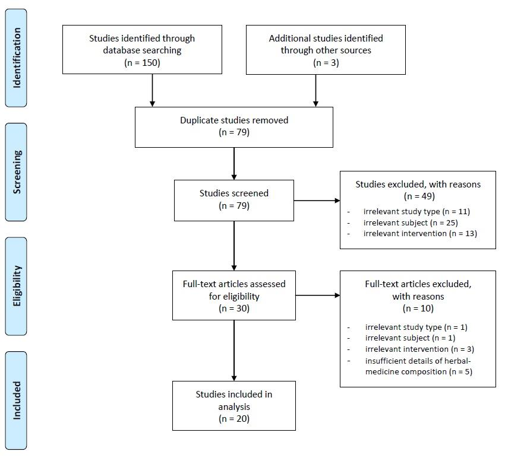

**Figure 1.** Flow chart of the study selection process. After literature searching, we identiﬁed a total of 153 studies, from

which 74 duplicate studies were excluded. We screened 79 studies’ titles and abstracts. As a result, 49 studies were excluded,

and 30 studies passed the ﬁrst round of the selection process. Of these 30 studies, 10 irrelevant studies were excluded again,

and the ﬁnal 20 studies were selected for this study. Of the 20 studies ﬁnally selected, 8 were experimental studies and 12

were clinical studies.

*3.1. Preclinical Studies*

Among the studies included in this analysis, there were eight preclinical studies [27–34]

The medicinal interventions used in the eight studies were largely divided into

three categories, namely medicinal compounds extracted from animal toxins in two stud-

ies [28,29], individual medicinal extracts in two studies [27,34], and medicinal decoctions

in four studies [30–33]. The composition of the medicinal formulae used in the four studies

is summarized in Table 1.

*Toxins* **2021**, *13*, 145

5 of 21

**Table 1.** Composition of the herbal medicines used in the included preclinical studies.

**First Author**

**(Year)**

**Herbal Medicine**

**Component**

Liu

(2014) [30]

Pingchongjiangnifang

Cinnamomi Ramulus 15 g, Draconis Sanguis 3 g, Trogopterorum Faeces

10 g, Typhae Pollen 6 g, Aquilariae Lignum 6 g, Hirudo 3 g, Liriopis seu

Ophiopogonis Tuber 10 g, Glycyrrhizae Radix et Rhizoma 6 g

Xu

(2018) [31]

Eleng Capsule

Curcumae Rhizoma 10 g, Sparganii Rhizoma 10 g, Salviae Miltiorrhizae

Radix 15 g, Curcumae Radix 15 g, Paeoniae Radix Rubra 15 g, Pelodiscis

Carapax 15 g, Hirudo 3 g

Liu

(2020) [32]

Huangzhi Neiyi Capsule

Hirudo 3 g, Rhei Radix et Rhizoma 9 g, Cyperi Rhizoma 6 g

Wang

(2005) [33]

Wudan Wan Modiﬁed Decoction

Salviae Miltiorrhizae Radix 10 g, Paeoniae Radix Rubra 10 g, Curcumae

Rhizoma 10 g, Cinnamomi Cortex 6 g, Corydalis Tuber 10 g, Hirudo 10 g,

Scolopendra two pieces, Pelodiscis Carapax 15 g, Sappan Lignum 10 g

Among the toxic animal-based medical materials, Hirudo was the most commonly

used in medicinal decoctions [30–33], followed by bufalin twice [28,29].

According to the eight studies, the underlying mechanisms of animal toxins against

(MMP)-9 expression [34], and anti-inﬂammatory effect [33] (Table 2).

*3.2. Clinical Studies*

In this analysis, we included a total of 12 clinical studies [35–46] examining the

therapeutic effects of herbal medicine containing animal toxins on endometriosis, of which

ﬁve were case series [35–39] and seven were randomized controlled trials (RCTs) [40–46].

According to these studies, dysmenorrhea was the most common symptom in patients

diagnosed with endometriosis, followed by infertility, pelvic mass, dyspareunia, pelvic

pain, mittelschmerz, and anal pain.

In all the clinical studies, medicinal decoctions were used. Quyu Jiedu Xiaozheng

Decoction was used in two studies, but at different doses [38,41]. Other than that, differ-

ent prescriptions were used in the remaining studies. The toxic animal-based medicinal

materials used in these studies include Hirudo, Scolopendra, Eupolyphaga, and Scor-

pio. Hirudo was used in a total of eight studies [35–37,39,40,43,44,46] at daily doses of

0.5 g [37], 1–2 g [43], 4–5 g [40], 6 g [39], 9 g [35], and 10 g [44,46]. Scolopendra was used

doses of 6 g [38,41], 10 g [46], and 12 g [35] per day. Scorpio was used in one study [42]

at a dose of 6 g per day. The administration duration varied from 1 to 9 months, with

3 months [36–38,44–46] being the most common. The timing of administration also varied;

some decoctions were discontinued during the menstrual period [35,39], administered

throughout the menstrual cycle [40,42,44,45], or administered after menstruation [37,46].

All included clinical studies reported improvement of symptoms related to endometrio-

sis, and three studies [37,42,45] reported that no side effects were observed (Table 3). The

dosing regimens of herbal medicines containing toxic animal-based medicinal materials in

the included clinical studies are presented in Table 4.

*Toxins* **2021**, *13*, 145

6 of 21

**Table 2.** Characteristics of the included preclinical studies.

**Study**

**ID**

**Author**

**(Year)**

**Study**

**Design**

**Herbal Medicine**

**(Toxic Animal-Based**

**Medicinal Materials)**

**Target Cells**

**(In Vitro)/Animal Model**

**(In Vivo)**

**Dosage**

**Treatment**

**Period**

**Outcome Measures**

**Results**

1

(2006)

[27]

In vivo

Bee venom (n.s.)

Female SD rats

(autotransplantation method)

0.1 mg/mL

(0.1 mL,

CV4)

6 weeks

(3 times/week)

1) Histological analysis (H&E)

2) Serum progesterone

3) Serum estradiol

4) Serum cytokines (TNF-α, IL-2, -4,

-6, -10)

1) Inhibited proliferation of endometrial

tissue

2) NSD

3) Decreased <sup>a</sup>

4) TNF-α, IL-4, NSDIL-2: Decreased <sup>a</sup>

IL-6, IL-10: Increased <sup>a</sup>

2

Nasu

(2005)

[28]

In vitro

Bufalin

(Bufonis Venenum)

Human endometrial cells

0, 0.001, 0.01,

0.1, 1,

10 ng/mL

-

1) Cell proliferation and cell viability

2) Apoptotic cells(%)

3) Cell cycle assay(ﬂow cytometry)

4) Apoptosis-related proteins and cell

cycle-related proteins

1) Decreased <sup>e</sup>

2) Increased <sup>d</sup>

3) G0/G1 cell cycle arrest observed <sup>c</sup>

4) Downregulated(Cyclin A, Bcl-2,

Bcl-XL proteins),

Upregulated(Bax, p21, cleaved

caspase-9 protein),

Unchanged(Cyclin B, cyclin D3, Fas,

Fas ligand, cleaved caspase-3, cleaved

caspase-8 protein)

3

Cho

(2018)

[29]

In vivo

Bufalin

(Bufonis Venenum)

Female C57BL/6 mice

(Autotransplantation method)

1 mg/kg

21 days

1) Volume of endometriotic lesions

2) Protein levels of the SRC-1 isoform

3) Protein levels of ERβ

1) Decreased <sup>b</sup>

2) Increased <sup>b</sup>

3) Decreased <sup>a</sup>

In vitro

Human

endometrial

cells

0, 10, 20, 50,

100, 200, 400,

800 nM

-

1) Intrinsic transcriptional activity of

the SRC-1 isoform

2) Intrinsic transcriptional activity of

ERβ3) Levels of PSMD2

4) Levels of Ki-67

5) Levels of active caspase 3

6) Levels of active IL-1β

7) Levels of caspase 1

8) Levels of ER-stress markers(PERK,

PDI, and BiP)

1) Increased <sup>b</sup>

2) NSD

3) Increased (epithelium <sup>d</sup>, stroma <sup>d</sup>)

4) Decreased (stroma <sup>c</sup>)

5) Increased (epithelium <sup>a</sup>)

6) Increased (stroma <sup>d</sup>)

7) Increased (stroma <sup>c</sup>)

8) PERK: Increased (epithelium <sup>d</sup>,

stroma <sup>d</sup>),

PDI: Increased (epithelium <sup>c</sup>, stroma <sup>d</sup>),

BiP: Increased (epithelium <sup>c</sup>, stroma <sup>a</sup>)

4

Liu

(2014)

[30]

In vitro

Pingchongjiangnifang(Hirudo)

Human endometrial cells

5%, 10%,

15%, 20% of

the drug in

serum

(1 mL)

-

1) Cell proliferation

2) Number of adherent cells

3) Number of invading cells

4) Apoptosis rate

1) Decreased <sup>a</sup>

2) Decreased <sup>a</sup>

3) Decreased <sup>a</sup>

4) Decreased <sup>b</sup>

*Toxins* **2021**, *13*, 145

7 of 21

**Table 2.** *Cont.*

**Study**

**ID**

**Author**

**(Year)**

**Study**

**Design**

**Herbal Medicine**

**(Toxic Animal-Based**

**Medicinal Materials)**

**Target Cells**

**(In Vitro)/Animal Model**

**(In Vivo)**

**Dosage**

**Treatment**

**Period**

**Outcome Measures**

**Results**

5

Xu

(2018)

[31]

In vivo

Eleng Capsule(Hirudo)

Female SD rats

(autotransplantation method)

4 g/kg

(high dose),

2 g/kg

(medium

dose),

1 g/kg

(low dose)

28 days

1) Volume of endometriotic foci

2) Histological analysis (H&E)

3) Serum levels of VEGF

4) Serum levels of bFGF

5) Serum levels of PDGF

6) Expression of VEGF

7) Expression of bFGF

8) Expression of PDGF

9) Expression of NF-κB

10) Expression of TLR4

1) Decreased (high <sup>a</sup>/medium <sup>a</sup>/low <sup>a</sup>)

2) Improved

3) Decreased (high <sup>b</sup>/medium <sup>b</sup>/low <sup>b</sup>)

4) Decreased (high <sup>b</sup>/medium <sup>b</sup>/low <sup>b</sup>)

5) Decreased (high <sup>b</sup>/medium <sup>a</sup>/low <sup>a</sup>)

6) Decreased (high <sup>b</sup>/medium <sup>b</sup>/low <sup>b</sup>)

7) Decreased (high <sup>b</sup>/medium <sup>b</sup>/low <sup>b</sup>)

8) Decreased (high <sup>b</sup>/medium <sup>b</sup>/low <sup>b</sup>)

9) Decreased (high <sup>b</sup>/medium <sup>b</sup>/low <sup>b</sup>)

10) Decreased (high <sup>b</sup>/medium

b/low b)

6

Liu

(2020)

[32]

In vivo

Huangzhi Neiyi Capsule

(Hirudo)

Female SD rats

(autotransplantation method)

9 g/kg

(high dose),

4.5 g/kg

(low dose)

28 days

1) PCNA

2) CD31

3) VEGF in peritoneal ﬂuid

4) mRNA expression of VEGF

5) mRNA expression of HIF-1α

1) Decreased <sup>a</sup>

2) Decreased <sup>a</sup>

2) Decreased (high <sup>a</sup>/low <sup>b</sup>)

3) Decreased (high <sup>b</sup>/low <sup>b</sup>),

4) Decreased (high <sup>b</sup>/low <sup>a</sup>)

7

Wang

(2005)

[33]

In vivo

Wudan Wan Modiﬁed

Decoction

(Hirudo, Scolopendra)

Female SD rats

(autotransplantation method)

1 mL/100 g

(26.56 g/kg)

(high dose),

1/2 diluted

(medium

dose),

1/4 diluted

(low dose)

28 days

1) TER for disappearance of ectopic

cysts

2) Effects on abdominal inﬂammation

3) TER for ectopic endometrial atrophy

1) Improved (medium <sup>a</sup>/high <sup>a</sup>), NSD

(low)

2) Less severe adhesion (medium/high),

More severe adhesion (low)

3) Improved (medium <sup>b</sup>/high <sup>a</sup>), NSD

(low)

8

Zhang

(2015)

[34]

In vivo

*Gloydius brevicaudus* venom

(Snake venom)

Female SD rats

(autotransplantation method)

0.75 mg/kg

(low dose),

1.5 mg/kg

(high dose)

3 weeks

1) Volume of ectopic foci

2) Expression of MMP-9

1) Decreased <sup>a</sup>

2) Decreased <sup>a</sup>

In vitro

Rat ectopic endometrial cells

Disintegrin

1.5 µg/mL

-

1) Expression of MMP-9

1) Decreased <sup>b</sup>

a *p* < 0.05; b *p* < 0.01; c *p* < 0.001; d *p* < 0.0001. SD rats: Sprague–Dawley rats; n.s.: not stated; n.r.: not reported; TER: total effectiveness rate; mo: month; NSD: no signiﬁcant difference; SRC-1: steroid receptor

coactivator-1; ERβ: estrogen receptor beta; PSMD2: proteasome 26S subunit, non-ATPase 2; IL: interleukin; PERK: protein kinase RNA-like endoplasmic reticulum kinase; PDI: protein disulﬁde isomerase;

BiP: binding immunoglobulin protein; H&E: hematoxylin and eosin staining; MMP-9: matrix metallopeptidase-9; VEGF: vascular endothelial growth factor; bFGF: basic ﬁbroblast growth factor; PDGF:

platelet-derived growth factor; NF-κB: nuclear factor kappa-light-chain-enhancer of activated B cells; TLR4: toll-like receptor 4; PCNA: proliferating cell nuclear antigen; CD31: cluster of differentiation 31;

HIF-1α: hypoxia-inducible factor 1-alpha.

*Toxins* **2021**, *13*, 145

8 of 21

**Table 3.** Characteristics of the included clinical studies.

**Study**

**ID**

**Author**

**(Year)**

**Study**

**Design**

**Sample**

**Size**

**(TG/CG)**

**Mean**

**Age** *±* **SD**

**(Min, Max)**

**Main Symptoms**

**Diagnostic Criteria**

**Intervention**

**Control**

**Intervention**

**Treatment**

**Period**

**Outcome Measures**

**Main Results**

**AE**

1

Wu

(1993)

[35]

Case

series

60

n.r.

(20,48)

Dysmenorrhea,

infertility,

menstrual disorder

Symptom,

gynecological exam,

ultrasonography

Herbal

medicine

-

n.r.

1) TER

91.67%

n.r.

2

Zhang

(2007)

[36]

Case

series

30

32

(23,43)

Dysmenorrhea,

mittelschmerz,

endometrioma

Symptom,

gynecological exam,

ultrasonography

Herbal

medicine

-

3 mo

VAS

Positive<sup>a</sup>

n.r.

3

Xu

(2007)

[37]

Case

series

52

n.r.

(23,46)

Dysmenorrhea,

pelvic pain, anal pain,

dyspareunia,

menstrual disorder,

infertility

Symptom,

gynecological exam,

ultrasonography

Herbal

medicine

-

3 mo

1) TER

88.46%

none

4

Zhang

(2007)

[38]

Case

series

78

34.5

(21,46)

Dysmenorrhea,

pelvic mass,

infertility

Gynecological exam,

ultrasonography,

laparoscopy

Herbal

medicine

-

3 mo

1) TER for

dysmenorrhea

2) TER for pelvic

mass

3) Pregnancy rate

(within 2 years)

1) 94.11%

2) 87.5%

3) 19.05%

n.r.

5

Feng

(2014)

[39]

Case

series

35

n.r.

(23,42)

Infertility

Symptom,

gynecological exam,

ultrasonography

Herbal

medicine

-

1–6 mo

1) TER for pregnancy

2) Spontaneous

abortion rate in early

pregnancy

1) 82.86%

2) 17.14%

n.r.

6

Han

(2009)

[40]

RCT

156

(78/78)

28.5

(18,48)

n.r.

Symptom,

laparoscopy

Herbal

medicine(A)

Herbal

medicine(B)

9 mo

1) TER

2) Pregnancy rate

3) Recurrence rate

1) Positive <sup>b</sup>

2) 11.53%(TG) vs

0%(CG)

3) Positive <sup>b</sup>

n.r.

7

Zhang

(2009)

[41]

RCT

128

(45/43/40)

n.r.

(n.r.)

Dysmenorrhea,

pelvic mass

Symptom,

gynecological exam,

ultrasonography,

laparoscopy,

antiendometrial

antibody, CA125

Herbal

medicine(A)

CG1: Herbal

medicine(B)

CG2: Herbal

medicine(C)

3–6 mo

1) TER

2) Dysmenorrhea

score

3) Pelvic mass score

1) Positive (vs CG1 <sup>a</sup>

/CG2 <sup>a</sup>)

2) Positive (vs CG1 <sup>b</sup>

/CG2 <sup>b</sup>)

3) Positive (vs CG1 <sup>b</sup>

/CG2 <sup>b</sup>)

n.r.

8

Lin

(2011)

[42]

RCT

70

(40/30)

n.r.

(n.r.)

Dysmenorrhea

Symptom,

ultrasonography,

CA125

Herbal

medicine

Mifepristone

6 mo

1) TER

2) TER for

dysmenorrhea

3) CA125

1) NSD

2) Positive <sup>a</sup>

3) Positive <sup>a</sup>

none

*Toxins* **2021**, *13*, 145

9 of 21

**Table 3.** *Cont.*

**Study**

**ID**

**Author**

**(Year)**

**Study**

**Design**

**Sample**

**Size**

**(TG/CG)**

**Mean**

**Age** *±* **SD**

**(Min, Max)**

**Main Symptoms**

**Diagnostic Criteria**

**Intervention**

**Control**

**Intervention**

**Treatment**

**Period**

**Outcome Measures**

**Main Results**

**AE**

9

Meng

(2012)

[43]

RCT

312

(156/156)

28.5

(18,48)

n.r.

Symptom,

gynecological exam,

ultrasonography

Herbal

medicine(A)

+Control

intervention

Herbal

medicine(B)

9 mo

1) TER

2) Pregnancy rate

3) Recurrence rate

1) Positive <sup>b</sup>

2) 11.54%(TG) vs

0%(CG)

3) Positive <sup>b</sup>

n.r.

10

Guo

(2013)

[44]

RCT

94

(48/46)

TG: 32.0*±*9.6

(22,42)

CG: 31.0*±*7.8

(23,40)

Infertility

Symptom,

gynecological exam,

ultrasonograph,

CA125

Herbal

medicine

+Control

intervention

Desogestrel

and Ethinyl

Estradiol

3 mo

Pregnancy rate

Positive <sup>b</sup>

n.r.

11

Liu

(2017)

[45]

RCT

72

(36/36)

n.r.

(24,45)

Dysmenorrhea

Symptom,

gynecological exam,

ultrasonography

Herbal

medicine

Sanjie

Zhentong

Capsule

3 mo

1) TER

2) VAS

1) Positive <sup>a</sup>

2) Positive <sup>a</sup>

none

12

Yi

(2018)

[46]

RCT

60

(30/30)

TG:

29.41*±*4.7

(n.r.)

CG:

30.0*±*4.1(n.r.)

Dysmenorrhea,

dyspareunia

Symptom,

ultrasonography,

antiendometrial

antibody, CA125

Herbal

medicine

+Control

intervention

Gestrinone

3 mo

1) TER

2) VAS

1) Positive <sup>a</sup>

2) Positive <sup>a</sup>

n.r.

a *p* < 0.05; b *p* < 0.01; c *p* < 0.001. TG: treatment group; CG: control group; SD: standard deviation; min: minimum; max: maximum; AE: Adverse event; n.r.: not reported; TER: total effectiveness rate; mo: month;

VAS: visual analog scale; RCT: randomized controlled trial; NSD: no signiﬁcant difference; CA125: cancer antigen 125. Positive means that there was an improvement in the outcome. A lower VAS, recurrence

rate, dysmenorrhea score, pelvic mass score, and CA124 meant an improvement with the status of endometriosis, and a higher TER indicated a better condition.

**Table 4.** Dosing regimens of herbal medicines containing toxic animal-based medicinal materials in the included clinical studies.

**Study ID**

**Author**

**(Year)**

**Herbal Medicine**

**Component**

**Toxic Animal-Based**

**Medicinal Materials**

**Dosage, Frequency**

**Dosing Period**

1

Wu

(1993)

[35]

n.r.

Sparganii Rhizoma 9 g, Curcumae Rhizoma 8 g,

Liquidambaris Fructus 9 g, Hirudo 9 g, Paeoniae Radix

Rubra 9 g, Manitis Squama 12 g, Eupolyphaga 12 g,

Moutan Radicis Cortex 12 g, Salviae Miltiorrhizae Radix

12 g, Cyperi Rhizoma 12 g, Prunellae Spica 12 g

Eupolyphaga, Hirudo

n.r.

Medication

discontinued during

menstruation

2

Zhang

(2007)

[36]

n.r.

Salviae Miltiorrhizae Radix, Persicae Semen, Corydalis

Tuber, Curcumae Rhizoma, Hirudo, Linderae Radix,

Olibanum, Myrrha, Cinnamomi Cortex

Hirudo

One dose per day, bid

n.r.

*Toxins* **2021**, *13*, 145

10 of 21

**Table 4.** *Cont.*

**Study ID**

**Author**

**(Year)**

**Herbal Medicine**

**Component**

**Toxic Animal-Based**

**Medicinal Materials**

**Dosage, Frequency**

**Dosing Period**

3

Xu

(2007)

[37]

Leech Tongluo Capsule

(Shuizhi tongluo jiaonang)

Hirudo 0.5 g, Manitis Squama 0.5 g, Astragali Radix 0.5 g,

Draconis Sanguis 0.5 g, Codonopsis Pilosulae Radix 0.5 g,

Sparganii Rhizoma 0.5 g, Curcumae Rhizoma 0.5 g,

Scolopendra 0.5 g, Cnidii Rhizoma 0.5 g, Glycyrrhizae

Radix et Rhizoma 0.5 g

Hirudo, Scolopendra

Six granules/time,

tid

From MCD 5

4

Zhang

(2007)

[38]

Quyu Jiedu Xiaozheng

Decoction

(Quyu Jiedu Xiaozheng tang)

Sargentodoxa cuneata 15–30 g, Hedyotidis Herba 15–30 g,

Astragali Radix 30 g, Coicis Semen 30 g, Scapharcae seu

Tegillarcae Concha 15 g, Litchi Semen 15 g, Cremastrae

Tuber 9–12 g, Draconis Sanguis 6–9 g, Olibanum 6–9 g,

Myrrha 6–9 g, Eupolyphaga 6 g, Scolopendra 1–2 pieces,

Agastachis Herba 9 g, Glycyrrhizae Radix et Rhizoma 6 g

Eupolyphaga, Scolopendra

One dose per day, n.r.

n.r.

5

Feng

(2014)

[39]

Xiaoyi Zhuyun tang

Angelicae Gigantis Radix 12 g, Paeoniae Radix Rubra

12 g, Paeoniae Radix Alba 12 g, Cyperi Rhizoma 12 g,

Morindae Radix 12 g, Patriniae Radix 12 g, Sparganii

Rhizoma 20 g, Curcumae Rhizoma 20 g, Astragali Radix

20 g, Galli Gigeriae Endothelium Corneum 20 g,

Gleditsiae Spina 20 g, Lycopi Herba 20 g, Dipsaci Radix

20 g, Drynariae Rhizoma 20 g, Eucommiae Cortex 20 g,

Coicis Semen 20 g, Bupleuri Radix 9 g, Hirudo 6 g, Cervi

Cornu 10 g

Hirudo

One dose per day, bid

From MCD 6 to MCD

15 (10 days)

6

Han

(2009)

[40]

A

n.r.

Hirudo 4–5 g

Hirudo

n.r., bid

From 3–4 days before

menstruation to the end

of menstruation

B

n.r.

Salviae Miltiorrhizae Radix 10–15 g, Angelicae Gigantis

Radix 8–10 g, Salvia chinensis Benth 8–10 g, Myrrha 10 g,

Sparganii Rhizoma 8 g, Leonuri Herba 8 g

7

Zhang

(2009)

[41]

Quyu Jiedu Xiaozheng

Decoction

(Quyu Jiedu Xiaozheng tang)

Sargentodoxa cuneata 30 g, Hedyotidis Herba 30 g, Coicis

Semen 30 g, Astragali Radix 30 g, Scapharcae seu

Tegillarcae Concha 15 g, Litchi Semen 15 g, Cremastrae

Tuber 10 g, Agastachis Herba 9 g, Scolopendra two pieces,

Draconis Sanguis 6 g, Eupolyphaga 6 g, Olibanum 6 g,

Myrrha 6 g, Glycyrrhizae Radix et Rhizoma 6 g

Eupolyphaga, Scolopendra

One dose per day, bid

n.r.

8

Lin

(2011)

[42]

Whole scorpion bergamot

powder

(Quanxie Foshou san)

Scorpio 6 g, Angelicae Gigantis Radix 15 g, Cnidii

Rhizoma 10 g, Leonuri Herba 15 g, Cyperi Rhizoma 15 g

Scorpio

One dose per day, n.r.

From 3–4 days before

menstruation

*Toxins* **2021**, *13*, 145

11 of 21

**Table 4.** *Cont.*

**Study ID**

**Author**

**(Year)**

**Herbal Medicine**

**Component**

**Toxic Animal-Based**

**Medicinal Materials**

**Dosage, Frequency**

**Dosing Period**

9

Meng

(2012)

[43]

A

n.r.

Hirudo 1–2 g

Hirudo

n.r., tid

From 3–4 days before

menstruation to the end

of menstruation

B

n.r.

Angelicae Gigantis Radix 10–15 g, Cnidii Rhizoma 6–10 g,

Leonuri Herba 15 g, Paeoniae Radix Rubra 10 g, Paeoniae

Radix Alba 10 g, Curcumae Longae Rhizoma 10 g,

Sparganii Rhizoma 10 g, Curcumae Rhizoma 10 g,

Sargentodoxa cuneata 30 g, Sepiae Endoconcha 12 g

10

Guo

(2013)

[44]

Bushen Quyu Decoction

(Bushen Quyu tang)

Lycii Fructus 15 g, Rehmanniae Radix Preparata 15 g,

Ligustri Lucidi Fructus 15 g, Cuscutae Semen 15 g,

Angelicae Gigantis Radix 10 g, Paeoniae Radix Rubra

15 g, Paeoniae Radix Alba 15 g, Achyranthis Radix 12 g,

Bupleuri Radix 10 g, Sappan Lignum 10 g, Sparganii

Rhizoma 10 g, Curcumae Rhizoma 10 g, Hirudo 10 g

Hirudo

One dose per day, bid

From MCD 1

11

Liu

(2017)

[45]

Tongjingxiao Granules

(Tongjingxiao keli)

Salviae Miltiorrhizae Radix 20 g, Paeoniae Radix Rubra

20 g, Angelicae Gigantis Radix 10 g, Scolopendra 6 g,

Corydalis Tuber 20 g, Meliae Fructus 10 g, Glycyrrhizae

Radix et Rhizoma 6 g

Scolopendra

One dose per day, bid

From 7 days before

menstruation to the end

of menstruation

12

Yi

(2018)

[46]

Xiaoyi Analgesic Soup

(Xiaoyi Zhitong tang)

Cinnamomi Ramulus 20 g, Poria Sclerotium 30 g, Salviae

Miltiorrhizae Radix 20 g, Persicae Semen 20 g, Curcumae

Rhizoma 10 g, Scolopendra two pieces, Eupolyphaga

10 g, Hirudo 10 g, Pelodiscis Carapax 20 g

Eupolyphaga, Hirudo,

Scolopendra

n.r., bid

From the end of

menstruation

n.r., not reported; bid, twice a day; tid, three times a day; MCD, menstrual cycle day.

*Toxins* **2021**, *13*, 145

12 of 21

**4. Discussion**

In this scoping review, we outlined preclinical and clinical studies of toxic animal-

based medicinal materials for the treatment of endometriosis. By reviewing the exper-

imental and clinical studies included in this study, we identiﬁed the potential of toxic

animal-based medicinal materials as a treatment of endometriosis. However, the current

evidence is insufﬁcient for establishing a standard for endometriosis treatment with toxic

animal-based medicinal materials. High-quality studies are needed to investigate the

various action mechanisms of toxic animal-based medical materials against endometriosis.

Even though we did not impose any restrictions in the literature search, we found more

studies published in China than in any other country. Traditional Korean medicine and

traditional Chinese medicine were alike as both are recognized by the healthcare systems

of those counties. However, in the healthcare systems of the two countries, traditional

Chinese medicine has a bigger share than that of traditional Korean medicine. Furthermore,

traditional Chinese medicine spans a broader range, as it includes not only traditional

Chinese medicine but also the integration of Chinese and Western medicine [47]. Therefore,

it is believed that there would be more cases of using toxic animal-based medicinal materials

in clinical contexts in China, with more reports for that matter.

The toxic animal-based medical materials investigated in the preclinical and clinical

studies included in this analysis were somewhat different. Hirudo and Scolopendra were

used in both preclinical and clinical studies. In contrast, Eupolyphaga and Scorpio were

used only in clinical studies, and bufalin, bee venom, and snake venom were used only in

preclinical studies. This is because Bufonis Venenum, bee venom, and snake venom are

animal-derived toxins that can cause serious side effects, including death [22,48–51], and

thus have not been traditionally used to treat endometriosis and benign disease. Although

these three animal venoms have recently been reported to exert proapoptotic [52–54]

and anti-inﬂammatory effects [55,56], there has been no clinical evidence of their beneﬁt

in endometriosis treatment. These three venoms are thought to be effective against en-

dometriosis because they have been reported to induce apoptosis, inhibit angiogenesis,

reduce estrogen levels, suppress MMP-9 expression, and exert anti-inﬂammatory effects

in preclinical studies. However, considering the serious side effects that may occur, the

in vitro and in vivo toxicity and action mechanisms of bufo venom, bee venom, and snake

venom must be elucidated before their efﬁcacy against endometriosis can be investigated

in clinical trials.

The 12 clinical studies included in this study reported improvement of various en-

dometriosis symptoms, such as dysmenorrhea, pelvic pain, dyspareunia, mittelschmerz,

anal pain, as well as increased pregnancy rate after administration of a decoction containing

Hirudo, Eupolyphaga, Scolopendra, and Scorpio. However, as there were differences in the

symptoms, dosage, and dosing period of the toxic animal-based medicinal materials used,

the evidence was considered insufﬁcient for establishing a standard for the application

of toxic animal-based medicinal materials in the treatment of endometriosis. In future

studies, the optimal dosage of the medicines should be established with consideration for

both efﬁcacy and toxicity, and clinical studies must be conducted to standardize the dosing

period and dosage.

The most widely used toxic animal-based medicinal material among the included

clinical studies was Hirudo Figure 2. Hirudo is the dried entire body of *Whitmania pigra*

Whitman, *Hirudo nipponica* Whitman, or *W. acranulata* Whitman, and is a representative

toxic animal-based medicinal material that has been used since the beginning of civilization.

It has the efﬁcacy of “breaking blood and expelling stasis”, and there is historical evidence

of its use in the treatment of endometriosis [22,57,58]. However, it is difﬁcult to conﬁrm

the effectiveness of Hirudo against endometriosis, as there were no studies examining

only Hirudo. Nevertheless, a medicinal decoction containing Hirudo was shown to exert

therapeutic effect against endometriosis in both preclinical and clinical studies.

*Toxins* **2021**, *13*, 145

13 of 21

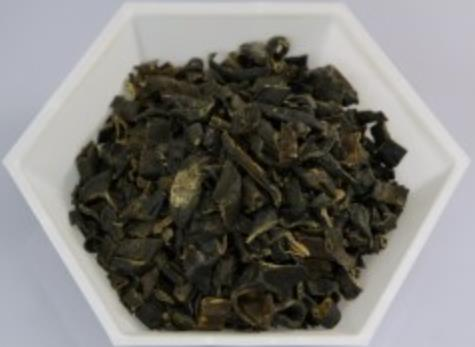

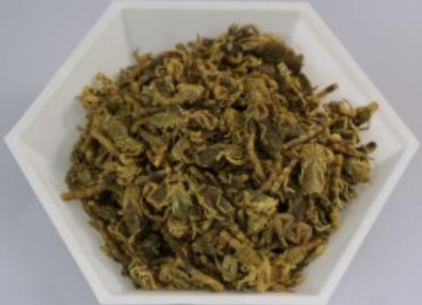

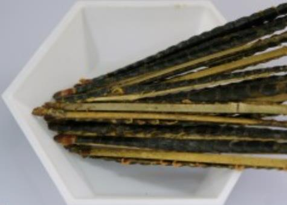

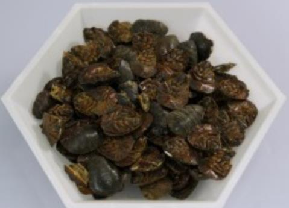

**Figure 2.** Toxic animal-based medicinal material in the includes clinical studies. (**A**) Hirudo: The

dried entire body of *Whitmania pigra* Whitman, *Hirudo nipponica* Whitman, or *W. acranulata* Whitman.

(**B**) Scorpio: The dried body of *Buthus martensii* Karsch scorpion. (**C**) Scolopendra: The dried body of

*Scolopendra subspinipes mutilans* L. Koch. (**D**) Eupolyphaga: The dried body of female *Eupolyphaga*

*sinensis* Walker or *Steleophaga plancyi* (Boleny).

In the studies included in this scoping review, medicinal decoctions containing Hirudo

was shown to downregulate the expression of hypoxia-inducible factor 1-alpha (HIF-1α)

and reduce the level of vascular endothelial growth factor (VEGF), thereby suppressing the

progression of endometriosis [32]. They also reduced the levels of basic ﬁbroblast growth

factor, platelet-derived growth factor, and VEGF, and were involved in the angiogenesis

pathway by downregulating TLR4 and NF-κB, which participate in the signaling process

of angiogenesis, thus improving endometriosis [31]. It was also suggested that a medical

decoction containing Hirudo exerted anti-inﬂammatory effect [33]. These ﬁndings are

supported by other experimental studies. Hirudo has been revealed to have anticoagulant,

anti-inﬂammatory, bacteriostatic, and analgesic effects [22,59]. Hirudo is also known to

inhibit tumor angiogenesis by improving the tumor hypoxia microenvironment, reducing

the mRNA and protein expression of HIF-1α, and contributing to the downregulation

of VEGF mRNA expression [60]. In addition, Hirudo induces apoptosis and inhibits cell

proliferation in Hep G2 human liver cancer cells and HL-60 leukemic cells, resulting in

an antitumor effect [61,62]. Although the use of Hirudo is controversial, Hirudo exerts

anti-inﬂammatory effect by inhibiting carboxypeptidases (kininase 1), inhibits platelet

function, exerts anticoagulant activity, and increases blood ﬂow [63].

Scolopendra was the second-most widely used toxic animal-based medicinal material

in the included clinical studies. Scolopendra is the dried body of *Scolopendra subspinipes*

*mutilans* L. Koch, which is poisonous. It has the efﬁcacy of “extinguishing wind and

suppressing convulsion, unblocking collaterals and relieving pain, counteracting toxins,

and dissipating masses” and is used for “spasm and convulsion due to internal stirring

of liver wind, etc.” [57]. Medicinal decoctions containing Scolopendra were shown to be

effective in treating endometriosis in both clinical and preclinical studies included in the

present review.

*Toxins* **2021**, *13*, 145

14 of 21

Experimental studies included in this study suggested that medical decoctions con-

taining Scolopendra may exert therapeutic effect against endometriosis, which is a chronic

inﬂammatory condition, through anti-inﬂammatory action [33]. This is supported by other

studies, in which Scolopendra was reported to have anticoagulation, antiseptic, and anti-

inﬂammatory effects [64–66]. Scolopendra is also known to induce the downregulation

of matrix metallopeptidase-2 (MMP-2) and -9 in tumor cells, suppress the migration and

invasion of tumor cells, and inhibit cell proliferation [67]. In addition, Scolopendra inhibits

the proliferation of EGFR-overexpressing cells by inducing apoptosis and modulating the

EGFR pathway [68,69]. It also exerts anti-inﬂammatory activity partially through inhibition

of the NF-κB signaling pathway [70].

Eupolyphaga, the third-most commonly used toxic animal-based medicinal mate-

rial in this review, is the dried body of female *Eupolyphaga sinensis* Walker or *Steleophaga*

*plancyi* (Boleny), which is slightly poisonous. It has the efﬁcacy of “breaking blood and

expelling stasis” and has been used clinically for “aggregation-accumulation due to static

blood obstruction” [57]. Clinical studies in this review revealed that medicinal decoctions

containing Eupolyphaga were effective in alleviating endometriosis symptoms. However,

there have been no experimental studies that elucidate the anti-endometriosis mechanism

of Eupolyphaga. Nevertheless, in other studies, Eupolyphaga was shown to inhibit cell

adhesion to ﬁbronectin and collagen IV as well as cell migration and invasion in A549

human lung cancer cell [71]. It also inhibits cell proliferation and reduces MMP-2 and -9

expression in hepatocellular carcinoma [72], and reduces cell invasive ability by downregu-

lating MMP-2 and -9 protein expression in breast cancer [73]. Furthermore, it induces the

detachment and apoptosis of A549 human lung cancer cells [71], inhibits tumor cell growth

in hepatocarcinoma, promotes TNF-α and IFN-γ expression, increases the Bax/Bcl-2 ratio,

and activates caspases-3 to induce apoptosis [74]. Moreover, Eupolyphaga is known to

activate the immune function by modulating oxidative systems, enhancing the phagocytic

function of macrophages, and elevating serum IL-2 level [75].

Lastly, the dried body of *Buthus martensii* Karsch scorpion is known to be poisonous

and exert liver-pacifying and wind-extinguishing effects. Scorpio has pharmacological

properties, such as pain-reducing, anti-inﬂammatory, and anticoagulant properties [76,77],

but no experimental studies have determined the therapeutic mechanism of Scorpio against

endometriosis. Scorpio exerts an antitumor effect by inhibiting cell proliferation, inducing

apoptosis, and decreasing migration and invasive functions in Hepa 1–6 cells and HepG2

cells [78,79]. They also inhibit MMP activity in breast and colorectal cancers, thereby

reducing the motility and invasion of tumor cells, and induce apoptosis by decreasing the

expression of antiapoptotic proteins and increasing that of proapoptotic proteins [80]. In

addition, chlorotoxin derived from scorpion toxin inhibits the expression of ERα in breast

cancer cells by inhibiting the ERα signaling pathway through direct binding to ERα, thus

changing the protein secondary structure of its LBD domain [81].

As outlined above, toxic animal-based medicinal materials are composed of several

molecules that exhibit a wide range of pharmacological activities. Considering that en-

dometriosis has several possible mechanisms of pathogenesis, multi-target medicines

have the potential to treat endometriosis through multiple pathways. Further research is

needed to elucidate the speciﬁc therapeutic mechanisms of individual toxic animal-based

medicinal materials against endometriosis. Although the mechanisms underlying the pro-

gression of endometriosis are still unclear, endocrine, immunologic, pro-inﬂammatory, and

pro-angiogenic processes are known to be involved in the development of endometriosis.

Considering the pharmacological effects of toxic animal-based medicinal materials on

endometriosis and other diseases, the possible action mechanisms of toxic animal-based

medicinal materials against endometriosis can be summarized as follows: induction of

apoptosis, antiangiogenesis effect, reduction of estrogen level, anti-inﬂammatory action,

and suppression of cell adhesion and invasion (Figure 3).

*Toxins* **2021**, *13*, 145

15 of 21

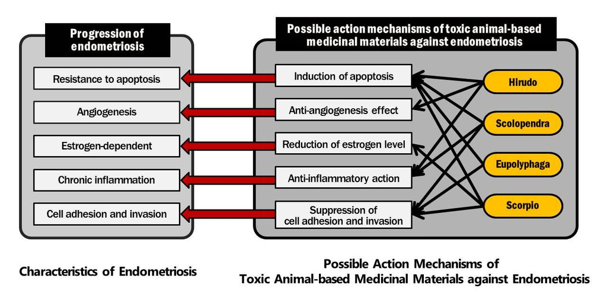

**Figure 3.** Possible action mechanisms of toxic animal-based medicinal materials against endometriosis.

Toxic animal-based medicinal materials may cause unwanted side effects due to their

toxic effects. Minimizing adverse events is an essential part of drug development. Even

with the medicines that have been used based on historical experience, the types and

frequency of adverse events must be identiﬁed. However, among the studies included in

this review, 75% of the studies had no reports on side-effects, and three studies [37,42,45]

reported that no side effects were observed after administration of herbal medicines con-

taining Hirudo and Scolopendra [37], Scolopendra [45], and Scorpio [42]. However, it was

not possible to ﬁnd any information on what kind of events they were monitoring.

The number of participants who participated in the studies that reported no side

effects was small. Since the known occurrence of adverse events was 5% to 10% [82,83],

the ﬁndings of this study are not sufﬁcient to support a conclusion that the administration

of toxic animal-based medicinal materials upon the patients with endometriosis would

result in no side effects. Even if the toxic animal-based medicinal materials have historical

evidence, it is necessary to identify the existence, occurrence rate, and severity of adverse

events through real data collection. A clinical study must be designed to report any adverse

events, no matter how insigniﬁcant they may look.

In addition, in order to identify the possible adverse events that can be caused by

toxic animal-based medicinal materials, we searched other studies that reported adverse

events after administering toxic animal-based medicinal materials. Among the studies

included in this review, three studies [37,42,45] reported that no side effects were ob-

served after administration of herbal medicines containing Hirudo and Scolopendra [37],

Scolopendra [45], and Scorpio [42], and that no adverse effects were reported following

the administration of herbal medicines containing Eupolyphaga. However, these ﬁndings

are inconsistent with those of other studies. Hirudo is prohibited for pregnant women,

patients with profuse menstruation or hemorrhagic tendency, patients with no blood stasis,

and weak patients because Hirudo is highly potent in breaking blood and expelling stasis,

unblocking the meridian, and eliminating mass [26,57]. Zeng et al. reported gastrointestinal

bleeding (1.9%) and cerebral hernia (0.9%) after the administration of herbal medicines

containing Hirudo and *Tabanus bivittatus* Matsumura in patients with acute intracerebral

hemorrhage [84]. Historically, owing to its toxicity, Scolopendra has not been used at a

high dosage, as its excessive use can damage healthy qi and cause early abortion [26];

therefore, it is prohibited for use in pregnant women and patients with blood deﬁciency

generating wind [57]. In one patient with chronic hepatitis B infection, hepatotoxicity was

reported after the administration of herbal medicine containing Scolopendra [85]. How-

*Toxins* **2021**, *13*, 145

16 of 21

ever, this herbal medicine contained not only Scolopendra but also the hepatotoxic Meliae

Fructus and Rhei Radix et Rhizoma [85]; these toxic effects cannot be attributed solely to

Scolopendra, but caution is needed when subjecting patients with chronic hepatitis B to

Scolopendra treatment. In traditional Chinese medicine, Eupolyphaga is contraindicated

for pregnant women because it may induce early abortion owing to its blood-breaking

and stasis- expelling efﬁcacies, and it should be used with caution in patients with no

blood stasis or patients with both blood deﬁciency and blood stasis [26]. Several studies

have reported the side effects of Eupolyphaga. However, in a study where 21 HIV/AIDS

patients were treated with a drug containing 20 g of Eupolyphaga twice a day for 4 months,

no side effects or toxic reactions were reported [86]. Scorpion should be prohibited in

patients with blood deﬁciency generating wind, and should be used at a dose range of

3–5 g owing to its toxicity [26,57]. There was one case of hepatotoxicity after administration

of herbal medicine containing Scorpio in a patient with chronic hepatitis B infection [85].

Taken together, the patient’s conditions should be considered when administering toxic

animal-based medicinal materials, and attention should be paid to the menstrual cycle

during treatment with these materials, as they can cause excessive bleeding in patients

with menorrhagia. In addition, when administering these medicinal materials to women of

childbearing age, the possibility of pregnancy should be assessed. Moreover, overuse of

these medicinal materials should be avoided because it has been reported to be associated

with hepatitis.

This is the ﬁrst study to review both preclinical and clinical studies investigating

the efﬁcacy of toxic animal-based medicinal materials in the treatment of endometriosis.

Our analysis results suggested the possible therapeutic mechanisms of toxic animal-based

medical materials against endometriosis and provided data as a reference for future transla-

tional studies. In addition, we included studies from major databases, such as PubMed and

Embase, and searched without language and date restrictions. However, there were some

limitations in this review. First, as we used only the biopharmaceutical names as search

terms, there is a possibility that potentially relevant articles not containing our search key

words and phrases in the titles or abstracts were not included in our analysis. Second, the

number of included studies was small. Third, it was difﬁcult to determine whether the

reported therapeutic effects were exerted by the toxic animal-based medicinal materials, as

these materials were used concomitantly with other medicinal materials. Fourth, there were

some factors that required attention in interpreting the study ﬁndings. Five of the clinical

studies we reviewed were case series, and therefore the level of evidence was somewhat

low. Seven RCTs did not provide their protocols and were without any description of

their randomization or blinding methods. Furthermore, some studies used mifepristone or

different types of herbal medicines rather than the conventional treatment of endometriosis

as control, so caution is needed as one interprets the results of these studies. Some studies

did not report side effects or what kind of important harms or unintended effects they

observed. Therefore, even if some studies did not report side effects, it does not necessarily

support the conclusion that toxic animal-based medicinal materials are safe to use. Lastly,

endometriosis is diagnosed by ascertaining symptoms, undertaking examination, and

performing laparoscopic surgery [87]. Of the studies that were included in this review,

test results, without any classiﬁcation of endometriosis, which were the limitations of

these studies.

Through this scoping review, we showed that toxic animal-based medicinal materials

might be effective as a clinical treatment of endometriosis. However, because the number of

clinical studies included was small and the intervention and treatment goals were different,

the ﬁndings of this review are insufﬁcient for establishing a standard for the application

of toxic animal-based medicinal materials as a treatment of endometriosis. In addition,

although toxic animal-based medicinal materials have been shown to be effective against

endometriosis in experimental studies, research on their speciﬁc therapeutic mechanisms

*Toxins* **2021**, *13*, 145

17 of 21

is still lacking. Therefore, evidence supporting the use of toxic animal-based medicinal

materials as a treatment of endometriosis is still limited, and further research is necessary.

The preclinical studies and clinical studies included in this review showed that the

most promising toxic animal-based medicinal material for endometriosis is likely to be

Hirudo. As shown in Figure 3, Hirudo, Scolopendra, and Scorpio meet three categories

of action mechanisms related to the progression of endometriosis. Eupolyphaga meets

two categories. In addition, in the clinical studies shown in Table 3, Hirudo was included

in eight studies. Scolopendra, Eupolyphaga, and Scoprpio were included in ﬁve, four,

and one study, respectively. Thus, we assume that Hirudo might be the most prominent

candidate for treating endometriosis, among these toxic animal-based medicinal materials.

The preclinical studies demonstrated that Hirudo has activities inducing apoptosis and

inhibiting angiogenesis and inﬂammation. Although these molecular mechanisms are

closely related to the progression of endometriosis, the anti-endometriotic efﬁcacy of

Hirudo was not fully demonstrated by a clinical study. In addition, there were no studies

that used Hirudo only, so further study is needed to examine the treatment effect of Hirudo

upon endometriosis. Scorpio, Scolopendra, and Eupholyphaga have been in clinical use,

but their preclinical study is not sufﬁcient. Bee venom, Bufonis Venenum, and snake

venom have been used in preclinical contexts, without any report of toxicity. As bee venom,

Bufonis Venenum, and snake venom may cause a serious adverse event, it is necessary to

identify the adverse events and appropriate doses via preclinical studies.

In the future, the following steps would have to be taken in order to develop a new

drug for endometriosis based on toxic animal-based medicinal materials. First, classical

literature and medical records should be searched to obtain additional evidence supporting

the use of toxic animal-based medicinal materials in clinical setting. Next, extensive

preclinical studies are needed to elucidate the mechanisms of endometriosis treatment that

are frequently used in clinical practice. Research is needed not only on the therapeutic

mechanism of a single toxic animal-based medicinal material against endometriosis but

also on the interaction between medicinal materials and decoctions that are traditionally

used in combinations, including toxic animal-based medicinal materials. As they have toxic

properties, quality control of single toxic animal-based medicinal materials is necessary,

and it is important to assess their safety and toxicity in future studies. Additional clinical

trials should be conducted to establish the standardized as well as optimal dosage and

dosing period of these medicinal materials.

**5. Conclusions**

In this scoping review, preclinical and clinical studies investigating the efﬁcacy of

toxic animal-based medicinal materials against endometriosis did not provide sufﬁcient

evidence to allow standardization of these materials as a treatment of endometriosis. How-

ever, the included studies have identiﬁed toxic animal-based medical materials as potential

treatments for endometriosis. In clinical studies, the administration of herbal medicines

containing toxic animal-based medicinal materials alleviated symptoms such as dysmenor-

rhea, infertility, endometrioma, and menstrual irregularities in patients with endometriosis,

antiangiogenesis effect, reduction of estrogen levels, and possibly, anti-inﬂammatory ac-

tion. Taken together, toxic animal-based medicinal materials are considered promising

to be developed as an effective treatment of endometriosis; however, additional studies

are needed.

**Author Contributions:** Conceptualization, S.-I.H. and J.-K.P.; methodology, S.-H.S. and J.-K.P.; data

classiﬁcation and interpretation of data, S.-I.H., S.-H.S., Y.-J.Y., and K.-T.H.; writing—original draft,

S.-I.H.; writing—review and editing, S.-H.S, K.-T.H, and J.-K.P.; supervision, J.-K.P.; project adminis-

tration, J.-K.P.; funding acquisition, J.-K.P. All authors have read and agreed to the published version

of the manuscript.

*Toxins* **2021**, *13*, 145

18 of 21

**Funding:** This research was supported by the National Research Foundation of Korea (NRF) grant

funded by the Korean government (MSIT) (No. NRF-2019R1G1A1100022).

**Institutional Review Board Statement:** Not applicable.

**Informed Consent Statement:** Not applicable.

**Data Availability Statement:** The data will be made available upon reasonable request.

**Acknowledgments:** Picture of Hirudo, Scorpio, Scolopendra, and Eupolyphaga used in this review

were prepared by the Koran Institute of Oriental Medicine in 2017, disclosed for open access under

Type 1 KOGL (Korea Open Government Licenses). The said copyright material can be download at

free of charge.

**Conﬂicts of Interest:** The authors declare that there are no conﬂict of interest regarding the publica-

tion of this paper.

**References**

1.

Bulun, S.E.; Yilmaz, B.D.; Sison, C.; Miyazaki, K.; Bernardi, L.; Liu, S.; Kohlmeier, A.; Yin, P.; Milad, M.; Wei, J. Endometriosis.

*Endocr. Rev.* **2019**, *40*, 1048–1079. [CrossRef]

2.

Zondervan, K.T.; Becker, C.M.; Koga, K.; Missmer, S.A.; Taylor, R.N.; Viganò, P. Endometriosis. *Nat. Rev. Dis.* **2018**, *4*, 9. [CrossRef]

3.

Shafrir, A.L.; Farland, L.V.; Shah, D.K.; Harris, H.R.; Kvaskoff, M.; Zondervan, K.; Missmer, S.A. Risk for and consequences of

endometriosis: A critical epidemiologic review. *Best Pract. Res. Clin. Obstet. Gynaecol.* **2018**, *51*, 1–15. [CrossRef]

4.

Zondervan, K.T.; Becker, C.M.; Missmer, S.A. Endometriosis. *N. Engl. J. Med.* **2020**, *382*, 1244–1256. [CrossRef]

5.

Falcone, T.; Flyckt, R. Clinical Management of Endometriosis. *Obstet. Gynecol.* **2018**, *131*, 557–571. [CrossRef]

6.

Peiris, A.N.; Chaljub, E.; Medlock, D. Endometriosis. *JAMA* **2018**, *320*, 2608. [CrossRef] [PubMed]

7.

Czyzyk, A.; Podﬁgurna, A.; Szeliga, A.; Meczekalski, B. Update on endometriosis pathogenesis. *Minerva Ginecol.* **2017**, *69*,

447–461. [CrossRef] [PubMed]

8.

Flores, I.; Rivera, E.; Ruiz, L.A.; Santiago, O.I.; Vernon, M.W.; Appleyard, C.B. Molecular proﬁling of experimental endometriosis

identiﬁed gene expression patterns in common with human disease. *Fertil. Steril.* **2007**, *87*, 1180–1199. [CrossRef] [PubMed]

9.

Van Gorp, T.; Amant, F.; Neven, P.; Vergote, I.; Moerman, P. Endometriosis and the development of malignant tumours of the

pelvis. A review of literature. *Best Pract. Res. Clin. Obstet. Gynaecol.* **2004**, *18*, 349–371. [CrossRef] [PubMed]

10.

Krupa, A.; Padała, O.; Putowski, M.; Konopelko, M.; Piasek, E. Available treatment methods for endometriosis. *J. Educ. Health*

*Sport.* **2019**, *9*, 178–184. [CrossRef]

11.

Practice Committee of the American Society for Reproductive Medicine. Treatment of pelvic pain associated with endometriosis:

A committee opinion. *Fertil. Steril.* **2014**, *101*, 927–935. [CrossRef] [PubMed]

12.

Bina, F.; Soleymani, S.; Toliat, T.; Hajimahmoodi, M.; Tabarrai, M.; Abdollahi, M.; Rahimi, R. Plant-derived medicines for treatment

of endometriosis: A comprehensive review of molecular mechanisms. *Pharmacol. Res.* **2019**, *139*, 76–90. [CrossRef] [PubMed]

13.

Meresman, G.F.; Götte, M.; Laschke, M.W. Plants as source of new therapies for endometriosis: A review of preclinical and clinical

studies. *Hum Reprod Update.* **2020**, dmaa039. [CrossRef] [PubMed]

14.

Zheng, W.; Wu, J.; Gu, J.; Weng, H.; Wang, J.; Wang, T.; Liang, X.; Cao, L. Modular Characteristics and Mechanism of Action of

Herbs for Endometriosis Treatment in Chinese Medicine: A Data Mining and Network Pharmacology–Based Identiﬁcation. *Front.*

*Pharmacol.* **2020**, *11*, 147. [CrossRef] [PubMed]

15.

Han, Y.F.; Hou, L.H.; Zhou, Y.J.; Wu, X.K. A survey of TCM treatment for endometriosis. *J. Tradit. Chin. Med.* **2009**, *29*, 64–70.

[CrossRef]

16.

Bae, K.Y.; Rhyu, M.R.; Roh, J.J.; Kim, D.I. Vasodilatory Activities and Safety of the Water Extracts of Three Medicinal Remedy in

Species of Insects. *J. Korean Obstet. Gynecol.* **2007**, *20*, 114–124.

17.

Sha, B.; Zhu, W.H. On the Application of Insect Medicine in Rheumatism from the Inheritance of Menghe Medical School.

*Rheumatism Arthritis* **2020**, *8*, 64–65.

18.

Wang, W.P.; Zou, J.; Wu, W. Case Records Illustration of Professor WU Wei Who has Used Insect Medicine to Treat Kidney

Disease. *J. Sichuan Tradit. Chin. Med.* **2020**, *7*, 85–87.

19.

Chen, Y.; Ji, L.; Wang, M.; Li, M.; Cui, S. Research Progress in the Application of Insect Medicinals in Gynecological Diseases.

*Shandong J. Tradit. Chin. Med.* **2020**, *9*, 1022–1025.

20.

Wang, J.H.; Wang, T.Z.; Jiang, D.Y. JIANG De-you’s experience in treating cardiovascular and cerebrovascular diseases with

insect drug. *China J. Tradit. Chin. Med. Pharm.* **2020**, *8*, 3962–3965.

21.

Klupczynska, A.; Pawlak, M.; Kokot, Z.J.; Matysiak, J. Application of Metabolomic Tools for Studying Low Molecular-Weight

Fraction of Animal Venoms and Poisons. *Toxins* **2018**, *10*, 306. [CrossRef] [PubMed]

22.

Bordon, K.C.F.; Cologna, C.T.; Fornari-Baldo, E.C.; Pinheiro-Júnior, E.L.; Cerni, F.A.; Amorim, F.G.; Anjolette, F.A.P.; Cordeiro, F.A.;

Wiezel, G.A.; Cardoso, I.A.; et al. From Animal Poisons and Venoms to Medicines: Achievements, Challenges and Perspectives in

Drug Discovery. *Front. Pharmacol.* **2020**, *11*, 1132. [CrossRef]

*Toxins* **2021**, *13*, 145

19 of 21

23.

Chatterjee, B. Animal Venoms have Potential to Treat Cancer. *Curr. Top. Med. Chem.* **2018**, *18*, 2555–2566. [CrossRef]

24.

Ravi, K.U. Use of Animal Venom Peptides/Toxins in Cancer Therapeutics. *Nat. Biomed. Eng.* **2018**, *16*, 1–26. [CrossRef]

25.

Choi, G. Animal-based medicinal materials in the pharmacopeias of Northeast Asian countries. *Korean Herb. Med. Inf.* **2018**, *6*,

203–230. [CrossRef]

26.

Herbology editorial committee of Korean medicine schools. *Herbology*; Yeonglimsa: Seoul, Korea, 2012; pp. 469–471, 546–548.

27.

Lim, E.-M.; Kwon, K.-R.; Lee, Y.-H. Effects of Bee Venom Acupuncture on Surgically Induced Endometriosis Rats. *J. Pharmacopunct.*

**2006**, *9*, 21–32.

28.

Nasu, K.; Nishida, M.; Ueda, T.; Takai, N.; Bing, S.; Narahara, H.; Miyakawa, I. Bufalin induces apoptosis and the G0/G1 cell

cycle arrest of endometriotic stromal cells: A promising agent for the treatment of endometriosis. *Mol. Hum. Reprod.* **2005**, *11*,

817–823. [CrossRef]

29.

Cho, Y.J.; Lee, J.E.; Park, M.J.; O’Malley, B.W.; Han, S.J. Bufalin suppresses endometriosis progression by inducing pyroptosis and

apoptosis. *J. Endocrinol.* **2018**, *237*, 255–269. [CrossRef]

30.

Liu, Y.L. Investigate the role of “Pingchongjiangnifang” of the in vitro culture of human endometrial stromal cells. Master’s

Thesis, Jiangxi University of Traditional Chinese Medicine, Nanchang, China, 1 May 2014.

31.

Xu, Z. Data Mining and Experimental Research on the Treatment of Endometriosis Dysmenorrhea by Professor Si Tuyi, a Famous

Chinese Medicine Practitioner. Ph.D. Thesis, Guangzhou University of Chinese Medicine, Guangzhou, China, 1 April 2018.

32.

Liu, H.; Sun, X.; Zhao, Y.; Xia, M.; Wang, C. Anti-angiogenesis effect and mechanism study of Huangzhi Neiyi capsule in a rat

endometriosis model. *J. Int. Med. Res.* **2020**, *48*, 300060519899767. [CrossRef] [PubMed]

33.

Wang, T.F. The Effect of Wudanwan Modiﬁed Formula on Rat Endometriosis Model. Master’s Thesis, Beijing University of

Chinese Medicine, Beijing, China, 1 May 2005.

34.

Zhang, Q. Effects of Disintegrin of *Gloydius Brevicaudus* Venom on Endometriosis of Rat and Its Mechanism. Master’s Thesis,

Fujian Medical University, Fuzhou, China, 1 June 2015.

35.

Wu, X. Treatment of 60 cases of endometriosis by dissolving blood and removing blood stasis. *Shaanxi Tradit. Chin. Med.* **1993**,

*14*, 530.

36.

Zhang, L. Professor Wang Ziyu’s Experience in Treating Endometriosis Dysmenorrhea. Master’s Thesis, Beijing University of

Chinese Medicine, Beijing, China, 1 May 2007.

37.

Xu, Y.; Su, J.; Cao, H. Shuizhi Tongluo Capsule in the treatment of 52 cases of endometriosis. *Hebei Tradit. Chin. Med.* **2007**, *29*, 797.

38.

Zhang, X.; Wang, W. Clinical analysis of 78 cases of endometriosis treated with Quyu Jiedu Xiaozheng Decoction. *Mod. Chin.*

*Med.* **2007**, *27*, 18–19.

39.

Feng, D. Xiaoyi Zhuyun Decoction in the treatment of 35 cases of endometriotic infertility. *Res. Chin. Med.* **2014**, *27*, 36–37.

40.

Han, D.; Yu, F.; Wang, H. Clinical observation on 78 cases of endometriosis treated with traditional Chinese medicine leech. *Chin.*

*J. Coal Ind. Med.* **2009**, *12*, 303–304.

41.

Zhang, X.; Dong, L.; Wang, Q. Treatment of 45 cases of endometriosis with Quyu Jiedu Xiaozheng Decoction. *Shaanxi J. Tradit.*

*Chin. Med.* **2009**, *30*, 260–261.

42.

Lin, H.; Xiao, W.; He, X.; Peng, J. Observation on the clinical efﬁcacy of Quanxie Foshou Powder in the treatment of endometriosis.

*Lishizhen Med. Mater. Med.* **2011**, *22*, 2819–2820.

43.

Meng, W.; Xu, Y. Clinical observation of 156 cases of endometriosis treated with traditional Chinese medicine leech. *J. Changchun*

*Univ. Tradit. Chin. Med.* **2012**, *28*, 128–129.

44.

Guo, M.; Qi, S.; Niu, G.; Liu, Z. Bushen Quyu Decoction combined with desogestrel and ethinyl estradiol tablets in the treatment

of 48 cases of infertility with endometriosis after laparoscopic surgery. *J. Tradit. Chin. Med.* **2013**, *26*, 26–28.

45.

Liu, H. Self-Made Dysmenorrhea Particles in the Treatment of Dysmenorrhea Caused by Endometriosis (Qi and Blood Stasis

Type) the Safety and Clinical Research. Master’s Thesis, Changchun University of Traditional Chinese Medicine, Changchun,

China, 1 March 2017.

46.

Yi, S.; Liu, L. The clinical study of Xiaoyizhitong Decoction combined with gestrinone in the treatment of endometriosis. *Chin.*

*Med. Guide* **2018**, *16*, 215–216.

47.

Ko, C.R.; Ku, N.P.; Seol, S.S. A Comparative Study on the Traditional Medicine Policies between Korea and China: Focused on the

Second Korean Medicine Development Plan and the 12.5 Traditional Chinese Medicine Development Plan. *J. Korea Technol. Innov.*

*Soc.* **2014**, *17*, 421–447.

48.

Wei, W.L.; Hou, J.J.; Wang, X.; Yu, Y.; Li, H.J.; Li, Z.W.; Feng, Z.J.; Qu, H.; Wu, W.Y.; Guo, D.A. Venenum bufonis: An overview

of its traditional use, natural product chemistry, pharmacology, pharmacokinetics and toxicology. *J. Ethnopharmacol.* **2019**, *237*,

215–235. [CrossRef]

49.

Jang, S.; Kim, K.H. Clinical Effectiveness and Adverse Events of Bee Venom Therapy: A Systematic Review of Randomized

Controlled Trials. *Toxins* **2020**, *12*, 558. [CrossRef] [PubMed]

50.

Wei, J.M.; Zhu, M.W.; Zhang, Z.T.; Jia, Z.G.; He, X.D.; Wan, Y.L.; Wang, S.; Xiu, D.R.; Tang, Y.; Li, J.; et al. A multicenter, phase III

trial of hemocoagulase Agkistrodon: Hemostasis, coagulation, and safety in patients undergoing abdominal surgery. *Chin. Med. J.*

**2010**, *123*, 589–593. [PubMed]

51.

Xu, Y.Y.; Ma, X.H.; Zhang, S.J. Hemocoagulase agkistrodon-induced anaphylactic shock: A case report and literature review. *Int.*

*J. Clin. Pharmacol. Ther.* **2016**, *54*, 129–134. [CrossRef] [PubMed]

*Toxins* **2021**, *13*, 145

20 of 21

52.

Miao, Q.; Bi, L.L.; Li, X.; Miao, S.; Zhang, J.; Zhang, S.; Yang, Q.; Xie, Y.H.; Zhang, J.; Wang, S.W. Anticancer effects of bufalin on

human hepatocellular carcinoma HepG2 cells: Roles of apoptosis and autophagy. *Int. J. Mol. Sci.* **2013**, *14*, 1370–1382. [CrossRef]

53.

Qi, F.; Li, A.; Inagaki, Y.; Kokudo, N.; Tamura, S.; Nakata, M.; Tang, W. Antitumor activity of extracts and compounds from the

skin of the toad *Bufo bufo gargarizans* Cantor. *Int. Immunopharmacol.* **2011**, *11*, 342–349. [CrossRef]

54.

Liu, L.; Chen, B.A.; Qin, S.K. Anti-angiogenesis effect of arsenic trioxide plus cinobufacin on human hepatocarcinoma transplan-

tation model nude mice. *Chin. J. Integr. Tradit. West. Med.* **2011**, *31*, 67–72.

55.

Lee, J.A.; Son, M.J.; Choi, J.; Jun, J.H.; Kim, J.I.; Lee, M.S. Bee venom acupuncture for rheumatoid arthritis: A systematic review of

randomised clinical trials. *BMJ Open* **2014**, *4*, e006140. [CrossRef] [PubMed]

56.

Gazerani, P.; Cairns, B.E. Venom-based biotoxins as potential analgesics. *Expert Rev. Neurother.* **2014**, *14*, 1261–1274. [CrossRef]

57.

Xi, S.; Gong, Y. *Essentials of Chinese Materia Medica and Medical Formulas: New Century Traditional Chinese Medicine*; Elsevier

(Academic Press): London, UK, 2017; pp. 246–319.

58.

Lu, J.; Chen, X.; Xu, X.; Liu, J.; Zhang, Z.; Wang, M.; Li, X.; Chen, H.; Zhao, D.; Wang, J.; et al. Active polypeptides from Hirudo

inhibit endothelial cell inﬂammation and macrophage foam cell formation by regulating the LOX-1/LXR-α/ABCA1 pathway.

*Biomed. Pharmacother.* **2019**, *115*, 108840. [CrossRef] [PubMed]

59.

Dong, H.; Ren, J.X.; Wang, J.J.; Ding, L.S.; Zhao, J.J.; Liu, S.Y.; Gao, H.M. Chinese Medicinal Leech: Ethnopharmacology,

Phytochemistry, and Pharmacological Activities. *Evid.-Based Complement. Altern. Med.* **2016**, *2016*, 7895935. [CrossRef]

60.

Wu, Q.; Guo, J.; Lu, H.; Kong, Q. Impacts of leech hirudo and blister beetle mylabris on the angiogenesis of chick chorioallantonic

membrance. *World J. Integr. Tradit. West. Med.* **2010**, *5*, 855–857.

61.

Guo, Y.; Tian, X.; Xiao, Z. Study on inhibition effects of freeze-thawing leech extract on HepG2 cells. *Chin. J. Inf. Tradit. Chin. Med.*

**2009**, *16*, 30–31.

62.

Xiao, Y.S.; Liao, F.S.; Zhao, Z.D.; Zuo, A.R.; Zhu, D.C. Study on inhibitory functions of leech extract on HL60 cells in vitro

experiment. *J. Jiangxi Univ. Tradit. Chin. Med.* **2013**, *25*, 63–66.

63.

Sig, A.K.; Guney, M.; Uskudar Guclu, A.; Ozmen, E. Medicinal leech therapy-an overall perspective. *Integr. Med. Res.* **2017**, *6*,

337–343. [CrossRef]

64.

Lee, W.; Lee, J.; Kulkarni, R.; Kim, M.A.; Hwang, J.S.; Na, M.; Bae, J.S. Antithrombotic and antiplatelet activities of small-molecule

alkaloids from Scolopendra subspinipes mutilans. *Sci. Rep.* **2016**, *6*, 21956. [CrossRef] [PubMed]

65.

Park, Y.J.; Lee, H.Y.; Jung, Y.S.; Park, J.S.; Hwang, J.S.; Bae, Y.S. Antimicrobial peptide scolopendrasin VII, derived from the

centipede *Scolopendra subspinipes mutilans*, stimulates macrophage chemotaxis via formyl peptide receptor 1. *BMB Rep.* **2015**, *48*,

479–484. [CrossRef]

66.

Park, J.H.; Lee, S.R. Anti-inﬂammatory activities of *Scolopendra subspinipes mutilans* in RAW 264.7 cells. *J. Nutr. Health* **2018**, *51*,

323. [CrossRef]

67.

Zheng, L.; He, H.; Shen, X.; Sun, Y. Centipede *Scolopendra* suppresses cell growth in human epidermoid carcinoma cell A431.

*Bangladesh J. Pharmacol.* **2017**, *12*, 299. [CrossRef]

68.

Ma, W.; Liu, R.; Qi, J.; Zhang, Y. Extracts of centipede *Scolopendra subspinipes mutilans* induce cell cycle arrest and apoptosis in

A375 human melanoma cells. *Oncol. Lett.* **2014**, *8*, 414–420. [CrossRef]

69.

Ma, W.; Zhang, D.; Zheng, L.; Zhan, Y.; Zhang, Y. Potential roles of Centipede *Scolopendra* extracts as a strategy against

EGFR-dependent cancers. *Am. J. Transl. Res.* **2015**, *7*, 39–52.

70.

Hwang, L.; Ko, I.G.; Jin, J.J.; Kim, S.H.; Kim, C.J.; Jeon, J.W.; Han, J.H. *Scolopendra subspinipes mutilans* Extract Suppresses

Inﬂammatory and Neuropathic Pain In Vitro and In Vivo. *Evid.-Based Complement. Altern. Med.* **2018**, *2018*, 5057372. [CrossRef]

[PubMed]

71.

Wang, F.X.; Wu, N.; Wei, J.T.; Liu, J.; Zhao, J.; Ji, A.G.; Lin, X.K. A novel protein from *Eupolyphaga sinensis* inhibits adhesion,

migration, and invasion of human lung cancer A549 cells. *Biochem. Cell Biol.* **2013**, *91*, 244–251. [CrossRef]

72.

Zhang, Y.; Zhan, Y.; Zhang, D.; Dai, B.; Ma, W.; Qi, J.; Liu, R.; He, L. *Eupolyphaga sinensis* Walker displays inhibition on

hepatocellular carcinoma through regulating cell growth and metastasis signaling. *Sci. Rep.* **2014**, *4*, 5518. [CrossRef]

73.

Zhan, Y.; Zhang, H.; Liu, R.; Wang, W.; Qi, J.; Zhang, Y. *Eupolyphaga sinensis* Walker ethanol extract suppresses cell growth and

invasion in human breast cancer cells. *Integr. Cancer Ther.* **2016**, *15*, 102–112. [CrossRef]

74.

Ge, G.F.; Yu, C.H.; Yu, B.; Shen, Z.H.; Zhang, D.L.; Wu, Q.F. Antitumor effects and chemical compositions of *Eupolyphaga sinensis*

Walker ethanol extract. *J. Ethnopharmacol.* **2012**, *141*, 178–182. [CrossRef] [PubMed]

75.

Liu, H.; Yan, Y.; Zhang, F.; Wu, Q. The immuno-enhancement effects of tubiechong *(Eupolyphaga sinensis)* lyophilized powder in

cyclophosphamide-induced immunosuppressed mice. *Immunol. Investig.* **2019**, *48*, 844–859. [CrossRef] [PubMed]

76.

Shoukry, N.M.; Salem, M.L.; Teleb, W.K.; Abdel Daim, M.M.; Abdel-Rahman, M.A. Antinociceptive, antiinﬂammatory, and

antipyretic effects induced by the venom of Egyptian scorpion *Androctonus amoreuxi*. *J. Basic Appl. Zool.* **2020**, *81*, 56. [CrossRef]

77.

Tran, T.V.; Hoang, A.N.; Nguyen, T.T.T.; Phung, T.V.; Nguyen, K.C.; Osipov, A.V.; Ivanov, I.A.; Tsetlin, V.I.; Utkin, Y.N. Anticoag-

ulant activity of low-molecular weight compounds from *Heterometrus laoticus* scorpion venom. *Toxins* **2017**, *9*, 343. [CrossRef]

[PubMed]

78.

Yan, Y.Q.; Xie, J.; Wang, J.F.; Shi, Z.F.; Zhang, X.; Du, Y.P.; Zhao, X.C. Scorpion inhibits epithelial-mesenchymal transition and

metastasis of hepatocellular carcinoma. *Exp. Biol. Med. (Maywood)* **2018**, *243*, 645–654. [CrossRef]

79.

Kwon, K.B.; Kim, E.K.; Lim, J.G.; Jeong, E.S.; Shin, B.C.; Jeon, Y.S.; Kim, K.S.; Seo, E.A.; Ryu, D.G. Molecular mechanisms of

apoptosis induced by Scorpio water extract in human hepatoma HepG2 cells. *World J. Gastroenterol.* **2005**, *11*, 943–947. [CrossRef]

*Toxins* **2021**, *13*, 145

21 of 21

80.

Al-Asmari, A.K.; Riyasdeen, A.; Islam, M. Scorpion Venom Causes Upregulation of p53 and Downregulation of Bcl-x(L) and BID

Protein Expression by Modulating Signaling Proteins Erk(1/2) and STAT3, and DNA Damage in Breast and Colorectal Cancer

Cell Lines. *Integr. Cancer Ther.* **2018**, *17*, 271–281. [CrossRef]

81.

Wang, Y.; Li, K.; Han, S.; Tian, Y.H.; Hu, P.C.; Xu, X.L.; He, Y.Q.; Pan, W.T.; Gao, Y.; Zhang, Z.; et al. Chlorotoxin targets ERα/VASP

signaling pathway to combat breast cancer. *Cancer Med.* **2019**, *8*, 1679–1693. [CrossRef] [PubMed]

82.

Lazarou, J.; Pomeranz, B.H.; Corey, P.N. Incidence of adverse drug reactions in hospitalized patients: A meta-analysis of

prospective studies. *JAMA* **1998**, *279*, 1200–1205. [CrossRef] [PubMed]

83.

Coleman, J.J.; Pontefract, S.K. Adverse drug reactions. *Clin. Med. (Lond.)* **2016**, *16*, 481–485. [CrossRef] [PubMed]

84.

Zeng, L.; Tang, G.; Wang, J.; Zhong, J.; Xia, Z.; Li, J.; Chen, G.; Zhang, Y.; Luo, S.; Huang, G.; et al. Safety and efﬁcacy of herbal

medicine for acute intracerebral hemorrhage (CRRICH): A multicentre randomised controlled trial. *BMJ Open* **2019**, *9*, e024932.

[CrossRef]

85.

Yuen, M.F.; Tam, S.; Fung, J.; Wong, D.K.; Wong, B.C.; Lai, C.L. Traditional Chinese medicine causing hepatotoxicity in patients

with chronic hepatitis B infection: A 1-year prospective study. *Aliment. Pharmacol. Ther.* **2006**, *24*, 1179–1186. [CrossRef] [PubMed]

86.

Wei, J.A.; Sun, L.M.; Chen, Y.X. Effects of Ailing Granule on immuno-reconstruction in HIV/AIDS patients. *Chin. J. Integr. Tradit.*

*West. Med.* **2006**, *26*, 319–321.

87.

Johnson, N.P.; Hummelshoj, L.; Adamson, G.D.; Keckstein, J.; Taylor, H.S.; Abrao, M.S.; Bush, D.; Kiesel, L.; Tamimi, R.; Sharpe-

Timms, K.L.; et al. World Endometriosis Society consensus on the classiﬁcation of endometriosis. *Hum. Reprod.* **2017**, *32*, 315–324.

[CrossRef] [PubMed]